# Estudio variabilidad estructural proteica

30/01/2016

## Conjuntos de proteinas

### Conjunto teorico

370 mutantes de 1a6m (151 sitios) simuladas con el modelo mutacional LFENM con ANM *R0* = 12 y *Fmax* = 2 (solo para LFENM). Para determinar que sitios mutar, se alineo 1a6m con cada una de las proteinas del conjunto, se obtuvieron los indices de los sitios alineados pero mutados y se simularon 10 mutantes por cada par de proteinas, obteniendose un total de 370 mutantes. Luego, para el analisis, se tomaron como alineados los sitios alineados de 1a6m para cada par de proteinas.

### Conjunto experimental

37 proteinas de la familia de globins. Las proteinas tienen un promedio de identidad secuencial de 33%. El core del alineamiento de la familia es de 111 sitios.

La caracterizacion del conjunto experimental se muestra a continuacion:

```
##    pdbid nsites naligned identity       MSD
## 1  1bina    143      137 12.40876 7.5471114
## 2   1lh1    153      146 17.80822 6.3391033
## 3   1hlm    158      145 17.24138 3.8274526
## 4   1hlb    157      144 17.36111 4.0775551
## 5   2mm1    153      151 85.43046 0.2136829
## 6  1pmba    153      151 86.09272 0.1489570
## 7   1ymb    153      151 87.41722 0.2749614
## 8   1mbs    153      151 83.44371 1.8967312
## 9   1emy    153      151 80.79470 0.2091288
## 10  1lht    153      151 64.23841 0.3051038
## 11  1myt    146      144 43.75000 0.7913137
## 12 2pghb    146      145 27.58621 1.8719969
## 13 2hhbb    146      145 24.82759 1.9542936
## 14 1hdab    145      145 22.75862 2.0573174
```

[output cut: 23 more lines]

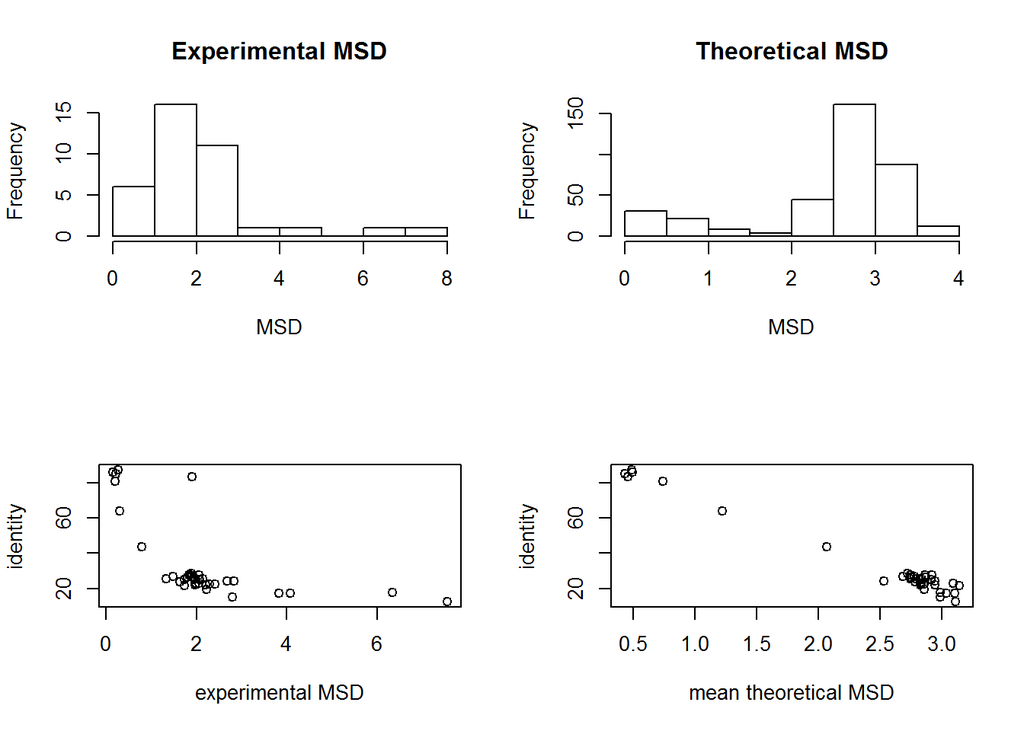

## Comparaciones

### RHO y AUC

Las distribuciones de *auc* y *rho* para cada conjunto se muestran a continuacion (azul= teorico, rojo = experimental)

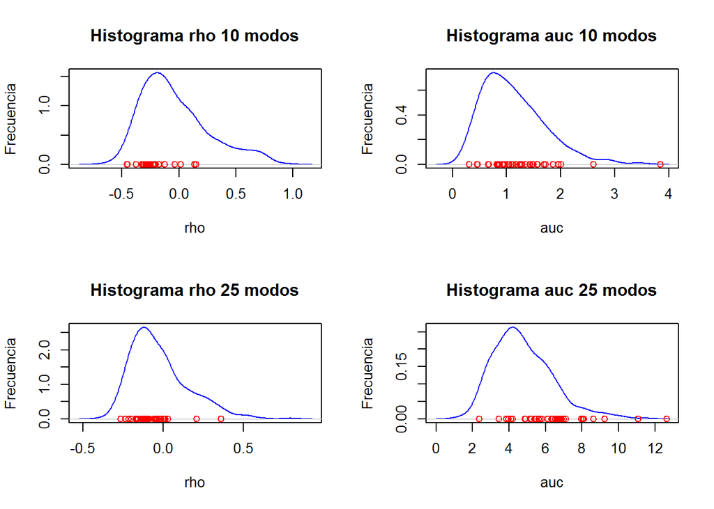

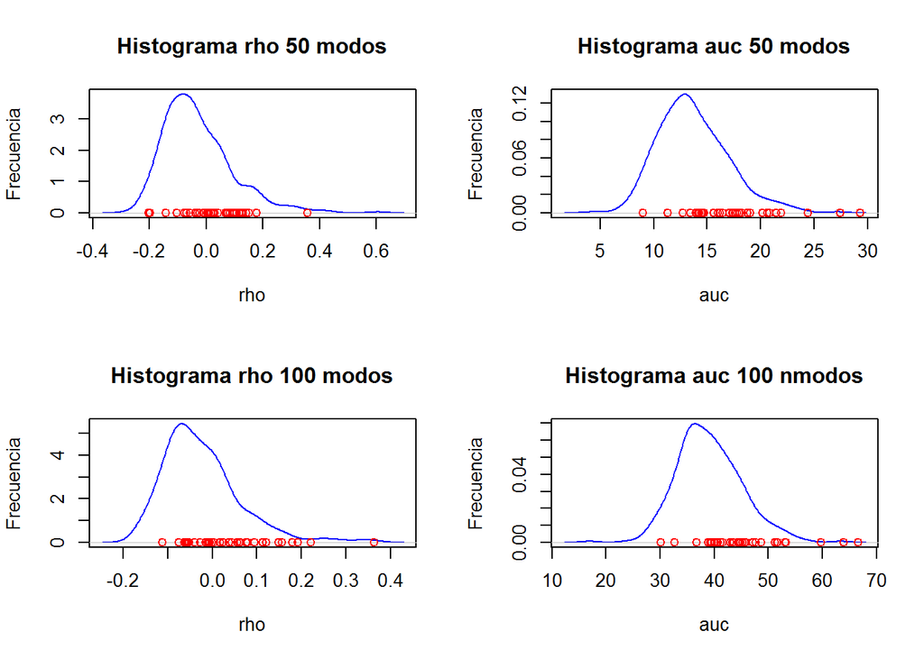

## Pn y Qn

Las distribuciones de *Pn* y *Qn* de los conjuntos son las siguientes:

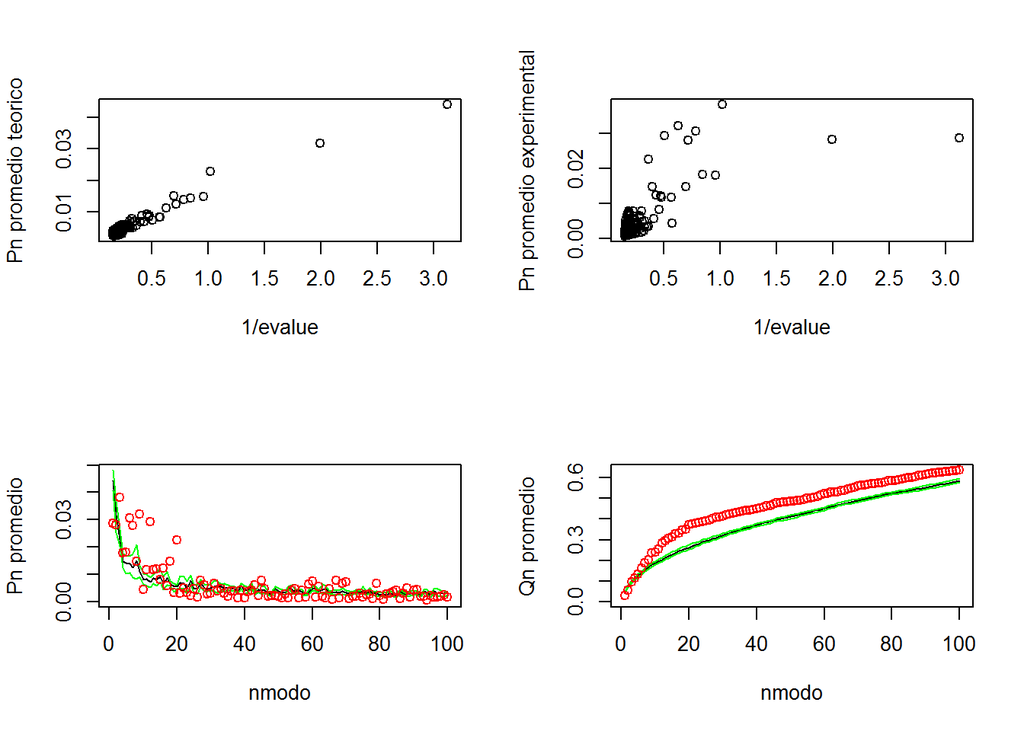

Negro: Teorico Rojo: Experimental Verdes: Cuartiles 0.05 y 0.95 de 10 grupos de 37 mutantes teoricas.